# K8S教學手冊

ted

2020/8/21

# OKD介紹

OKD (Origin Community Distribution) 是由 Red Hat 所發展的開源社區版本 OpenShift Origin，基於 Container 容器與 Kubernetes 為基底， 協助團隊實現快速的應用程序開發，輕鬆部署和擴展以及長期生命週期維護等工作。

指令部分與 kubectl 大致相同，只是把 kubectl 換成 oc

user可以透過 OpenShift OKD 平臺即服務(PaaS)上進行快速開發，從 Web UI 端配置帳戶來區隔開發者，使開發者可獨立發送需要測試運行的程式碼及部署服務，也能透過平台來實踐 CI/CD 測試等相關服務流程。  
透過 Monitor 監控節點狀態及資源管理，基於 Kubernetes Orchestrator 將能確保平台繼續運行，對於開發而言如果有新版本的容器映像檔版本 (Images Version)，OKD 平台能自動提取新版本並執行運行節點的滾動升級，對於保密性將透過容器、密碼和API_key等相關服務來保持叢集安全性，實踐功能強大的平台。

[figure not shown]

# OKD 本機實作–minishift介紹

Minishift是一種簡化版的OKD，可透過虛擬機啟動單節點OKD群集(single-node okd cluster)來協助在本機端運行OKD。 使用Minishift，可以在本機上操作並熟悉OKD的實際流程。Minishift可以在Windows，macOS和GNU/Linux操作系統上運行Minishift。Minishift使用libmachine來配置虛擬機，並使用OKD來運行集群。

[figure not shown]

# minishift 建置步驟與畫面

1.登入OKD官網，下載頁面download minishift並安裝 連結如下:  
https://github.com/minishift/minishift/releases

2.執行common line 並切換至該路徑下，並輸入安裝指令  
minishift.exe start –vm-driver virtualbox 輸入後按下enter開始安裝，如圖所示

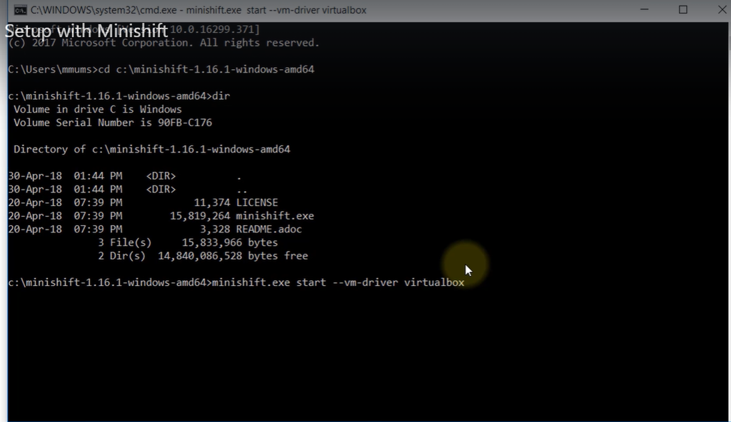

3.安裝後，可以得到OKD的web介面，如圖所示:

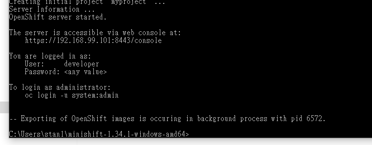

4.登入頁面與主畫面:

[figure not shown]

[figure not shown]

5.安裝OC指令，進入OKD官網，下載頁面download minishift並安裝 連結如下:  
https://www.openshift.com/blog/installing-oc-tools-windows

解壓縮後將oc.exe 放入 minishift下的資料夾如附圖:

[figure not shown]

在common line 輸入oc login 登入帳密即可

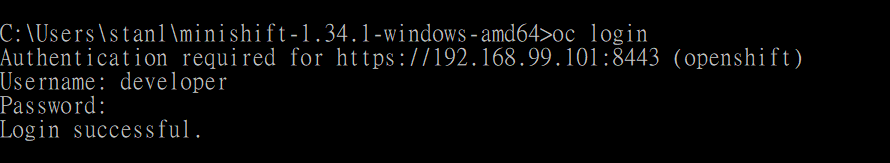

# OKD介面與功能介紹

一、部屬專案有三種方式:

1.deploy Image  
2.import YAML/JSON  
3.Select from Project(介面中 creat Project)

如圖所示:

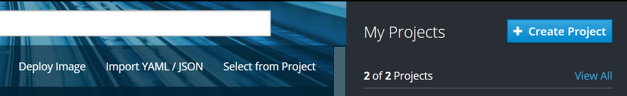

二、專案內部(Overview)  
可看到container、networking、service、builds相關資訊

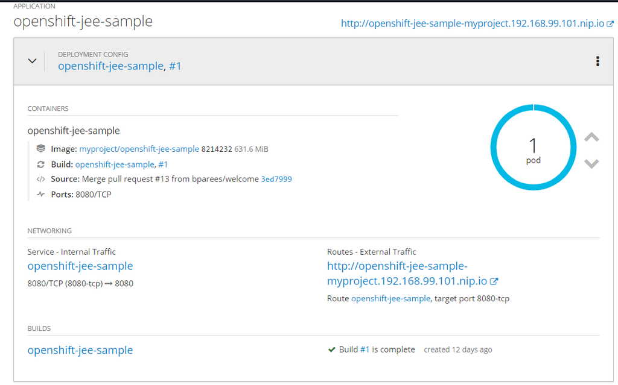